# ISLR - Exercises 09

Saad M. Siddiqui

4/11/2022

# Applied Exercises

## Exercise 04 - Linear vs Non-Linear SVMs

**Generate a simulated two-class data set with 100 observations and two features in which there is a visible but non-linear separation between the two classes. Show that in this setting, a support vector machine with a polynomial kernel (with degree greater than 1) or a radial kernel will outperform a support vector classifier on the training data. Which technique performs best on the test data? Make plots and report training and test error rates in order to back up your assertions.**

For simplicity, I will be using code similar to the one in the lab for generating a non-linearly separable data set of two classes and two features.

This takes some experimentation with the mean and standard deviation of the generating function.

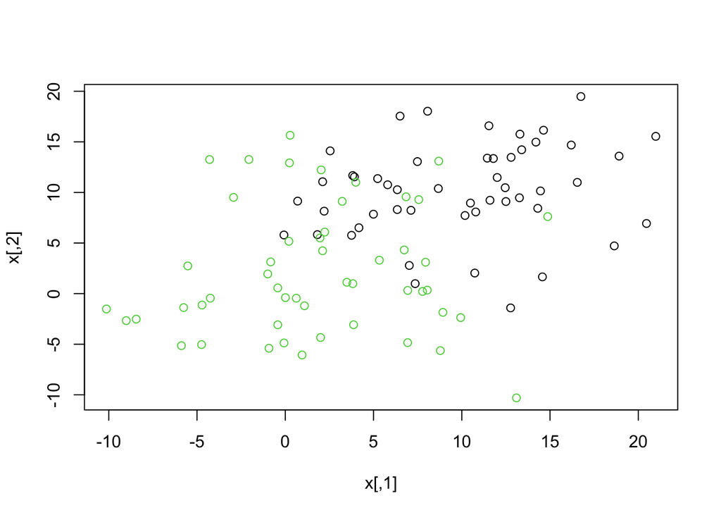

```r
set.seed(163)
n.observations <- 100
n.predictors <- 2

# Make a matrix of the data
x <- matrix(
  rnorm(n.observations * n.predictors, mean = 5, sd = 5),
  ncol = n.predictors
)

# Offset the features so that the decision boundary becomes non-linear
x[1:50, ] <- x[1:50, ] + 5
x[51:75, ] <- x[51:75, ] - 5
y <- c(rep(1, 50), rep(-1, 50))

# Render the plot to make sure the data is indeed not linearly separable
plot(x, col = 2 - y)
```

```r
# Make into a data.frame. Convert the target to a factor, otherwise
# svm will train a regression SVM
svm.data <- data.frame(x = x, y = as.factor(y))

# Randomly set up train and test indices
svm.train.idx <- sample(1:n.observations, 0.8 * n.observations)
svm.test.idx <- (-svm.train.idx)
```

We now fit a linear SVC, a radial basis SVC, and a polynomial SVC. In the case of the linear SVC, we can only tune the cost. In case of the polynomial and radial SVC, we can also additionally tune the polynomial degree and the $\gamma$ parameter respectively.

```
## The test error rate for Linear SVC is 0.25
```

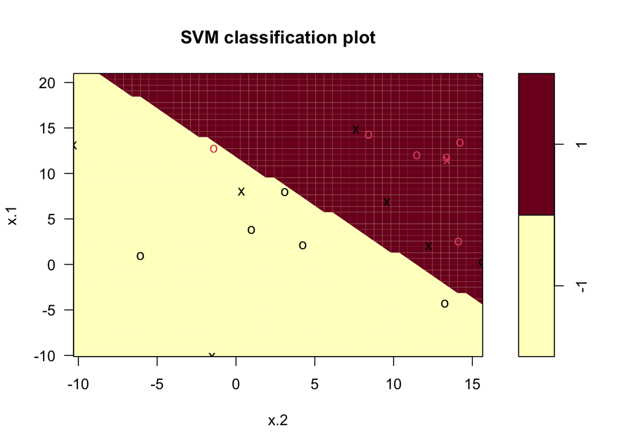

```r
# Seed random number generator and tune all three variants of SVC
set.seed(163)

# Because we are working with very limited data, use 5 folds only
svc.tune.control <- tune.control(cross = 5)

# Simple SVC
linear.svc.tune <- tune(svm, y ~., data = svm.data[svm.train.idx, ],
  ranges = list(cost = c(0.1, 1, 10, 100, 1000)),
  tunecontrol = svc.tune.control,
  kernel = 'linear'
)

# Polynomial SVC
poly.svc.tune <- tune(svm, y ~., data = svm.data[svm.train.idx, ],
  ranges = list(
    cost = c(0.1, 1, 10, 100, 1000),
    degree = c(1, 2, 3, 4, 5)
  ),
  tunecontrol = svc.tune.control,
  kernel = 'polynomial'
)

# Radial Basis SVC
radial.svc.tune <- tune(svm, y ~., data = svm.data[svm.train.idx, ],
  ranges = list(
    cost = c(0.1, 1, 10, 100, 1000),
    gamma = c(1, 3, 5, 7, 9)
  ),
  tunecontrol = svc.tune.control,
  kernel = 'radial'
)

# Use the best variant of each variant of the predictor on test data
linear.svc.best <- linear.svc.tune$best.model
poly.svc.best <- poly.svc.tune$best.model
radial.svc.best <- radial.svc.tune$best.model

evaluate_on_test_set <- function(my.svc, svc.str) {
  summary(my.svc)
  y.pred <- predict(my.svc, newdata = svm.data[svm.test.idx, ])
  table(y.pred, svm.data[svm.test.idx, ]$y)
  err.rate <- mean(y.pred != svm.data[svm.test.idx, ]$y)
  message("The test error rate for ", svc.str, " is ", round(err.rate, 4))
  message("---------------------------------------")
  plot(my.svc, data = svm.data[svm.test.idx,],
       main = paste0("SVM Classification Plot - ", svc.str))
}


evaluate_on_test_set(linear.svc.best, 'Linear SVC')
```

```r
evaluate_on_test_set(poly.svc.best, 'Polynomial SVC')
```

```
## The test error rate for Polynomial SVC is 0.35
## ---------------------------------------
```

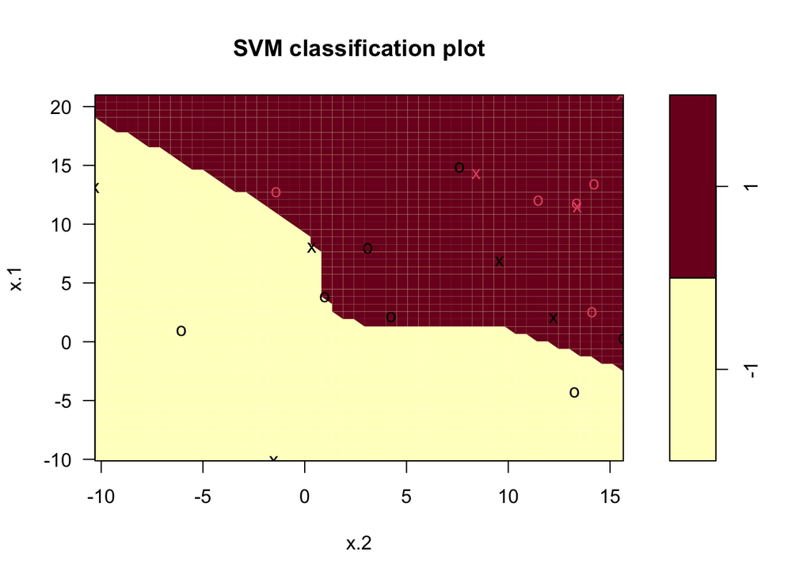

```r
evaluate_on_test_set(radial.svc.best, 'Radial Basis SVC')
```

```
## The test error rate for Radial Basis SVC is 0.2
## ---------------------------------------
```

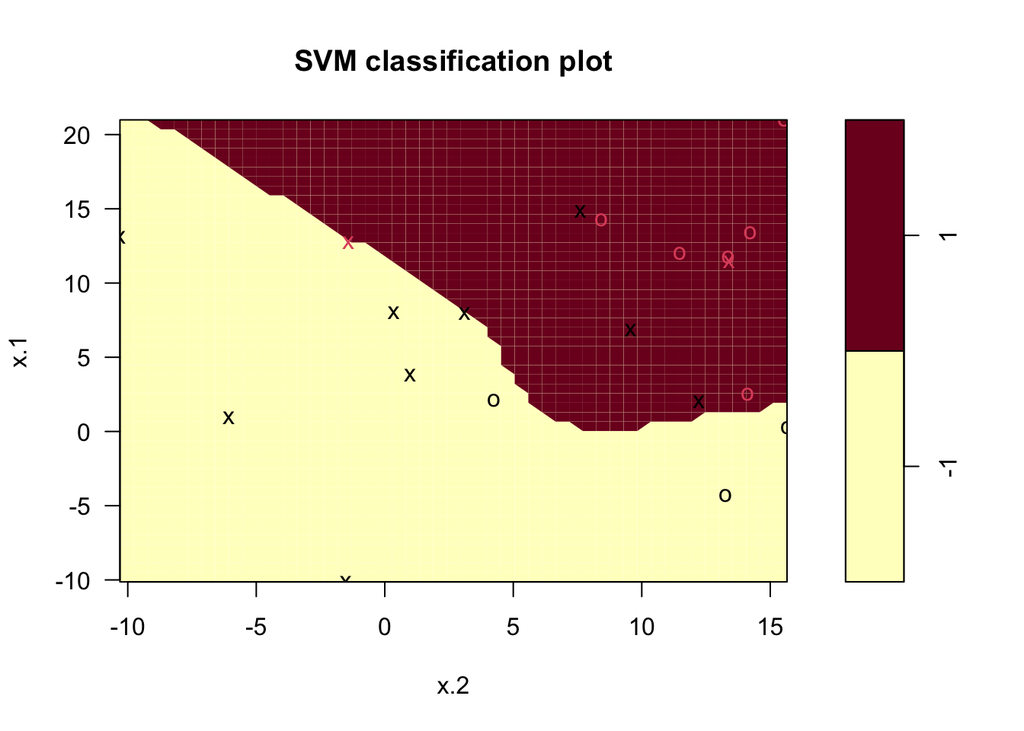

All three variants of the SVC have been trained on the same 80 data points and validated on the same 20 data points.

All of them have also undergone hyperparameter tuning where necessary to ensure that in each case, the best possible SVC is being used on the test data.

Based on the test set performance, it looks like the polynomial SVC of degree 3 followed by the linear SVC and then the radial basis SVC.

The test error rate is highest for the polynomial SVC of degree 3, followed by the linear SVC, and then finally the radial basis SVC.

This result is slightly counterintuitive since I expected test error rate for linear SVC to be highest, given its linear decision boundary. The polynomial decision boundary seems to be a mixture of the radial decision boundary and the linear boundary, but does worse than both of them. Maybe a different cost parameter was required here. Radial basis does much better than either, although it does seem to have more margin violations.

## Exercise 05 - Non-linear Logistic Regression

**We have seen that we can fit an SVM with a non-linear kernel in order to perform classification using a non-linear decision boundary. We will now see that we can also obtain a non-linear decision boundary by performing logistic regression using non-linear transformations of the features.**

### Part (a)

**Generate a data set with $n = 500$ and $p = 2$, such that the observations belong to two classes with a quadratic decision boundary between them.**

```r
set.seed(163)
x1 <- runif(500) - 0.5
x2 <- runif(500) - 0.5
y <- 1 * (x1^2 - x2^2 > 0)
```

### Part (b)

**Plot your observations, colored according to their class labels. Your plot should display $X_1$ on the x-axis, and $X_2$ on the y-axis.**

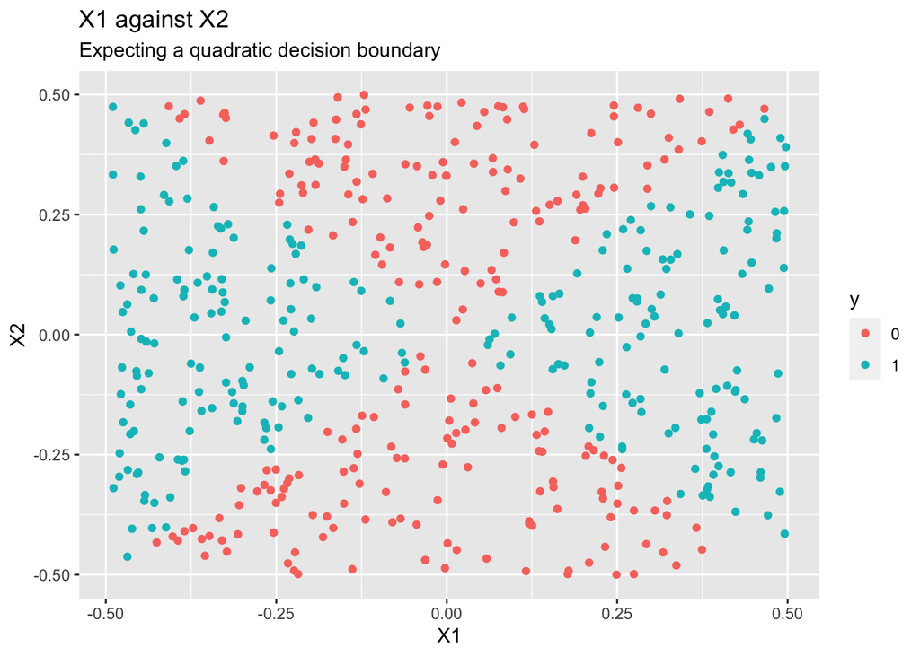

```r
non.linear.data <- data.frame(x1 = x1, x2 = x2, y = as.factor(y))
non.linear.data %>% ggplot(aes(x = x1, y = x2, col = y))  +
  geom_point() +
  labs(x = 'X1', y = 'X2', title = 'X1 against X2',
       subtitle = 'Expecting a quadratic decision boundary')
```

### Part (c)

**Fit a logistic regression model to the data using $X_1$ and $X_2$ as predictors.**

```r
log.reg.fit <- glm(y ~ ., data = non.linear.data, family = binomial)
summary(log.reg.fit)
```

```
##
## Call:
## glm(formula = y ~ ., family = binomial, data = non.linear.data)
##
## Deviance Residuals:
##    Min      1Q  Median      3Q     Max
## -1.235  -1.200   1.127   1.150   1.182
##
## Coefficients:
##             Estimate Std. Error z value Pr(>|z|)
## (Intercept)  0.06507    0.08956   0.727    0.468
## x1           0.04154    0.30518   0.136    0.892
## x2          -0.11728    0.31430  -0.373    0.709
##
## (Dispersion parameter for binomial family taken to be 1)
##
##     Null deviance: 692.64  on 499  degrees of freedom
## Residual deviance: 692.48  on 497  degrees of freedom
## AIC: 698.48
##
## Number of Fisher Scoring iterations: 3
```

### Part (d)

**Apply this model to the training data in order to obtain the predicted class label for each training observation. Plot the observations, colored according to the predicted class labels. The decision boundary should be linear.**

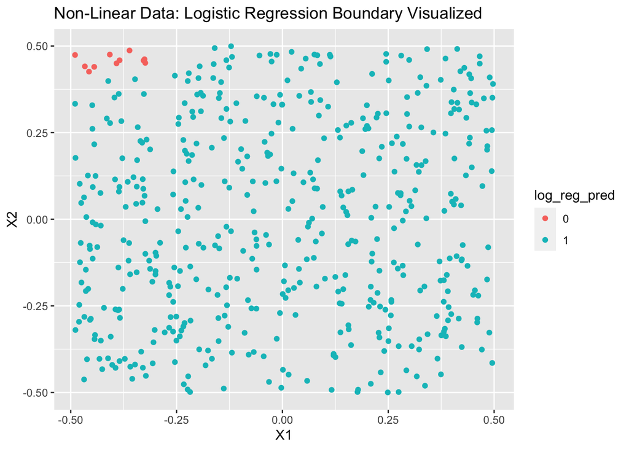

```r
log.reg.pred <- predict(log.reg.fit, newdata = non.linear.data, type = 'response')
log.reg.pred <- factor(ifelse(log.reg.pred > 0.5, 1, 0))
non.linear.data[['log_reg_pred']] <- log.reg.pred
non.linear.data %>%
  ggplot(aes(x = x1, y = x2, col = log_reg_pred)) +
  geom_point() +
  labs(x = 'X1', y = 'X2', title = 'Non-Linear Data: Logistic Regression Boundary Visualized')
```

The decision boundary is linear. However, we find that it has very little overlap with the actual classes. So the linear model completely fails to capture the non-linearty inherent in the data generating process.

### Part (e)

**Now fit a logistic regression model to the data using non-linear functions of $X_1$ and $X_2$ as predictors (e.g. $X_1^2$, $X_2^2$, $X_1 \times X_2$, $log(X_2)$).**

Using 2nd order polynomial variants for both $X_1$ and $X_2$.

```r
log.reg.poly.fit <- glm(y ~ poly(x1, 2) + poly(x2, 2) - log_reg_pred,
                        data = non.linear.data,
                        family = 'binomial')
summary(log.reg.poly.fit)
```

```
##
## Call:
## glm(formula = y ~ poly(x1, 2) + poly(x2, 2) - log_reg_pred, family = "binomial",
##     data = non.linear.data)
##
## Deviance Residuals:
##        Min          1Q      Median          3Q         Max
## -1.648e-03  -2.000e-08   2.000e-08   2.000e-08   1.574e-03
##
## Coefficients:
##                Estimate Std. Error z value Pr(>|z|)
## (Intercept)       59.56  160379.31   0.000    1.000
## poly(x1, 2)1   -1652.83  319272.53  -0.005    0.996
## poly(x1, 2)2   33591.59 8348760.36   0.004    0.997
## poly(x2, 2)1   -3820.20 3297719.96  -0.001    0.999
## poly(x2, 2)2  -33436.42 6104461.50  -0.005    0.996
##
## (Dispersion parameter for binomial family taken to be 1)
##
##     Null deviance: 6.9264e+02  on 499  degrees of freedom
## Residual deviance: 5.4034e-06  on 495  degrees of freedom
## AIC: 10
##
## Number of Fisher Scoring iterations: 25
```

We now get a quadratic fit, just as expected.

### Part (f)

**Apply this model to the training data in order to botain a predicted class label for each training observation. Plot the observations, colored according to the predicted class labels. THe decision boundary should obviously be non-linear.**

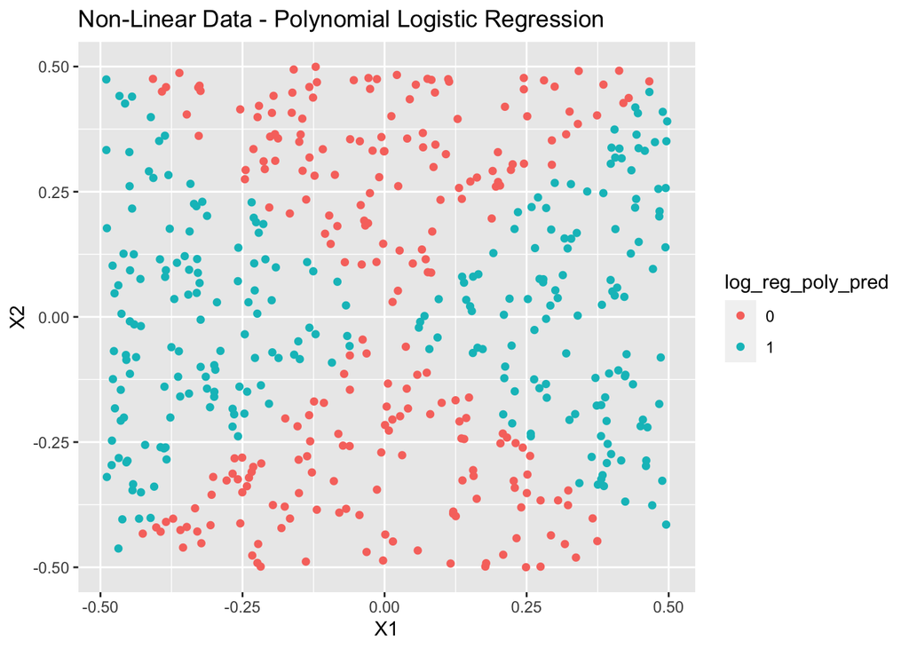

```r
log.reg.poly.pred <- factor(ifelse(predict(log.reg.poly.fit, newdata = non.linear.data, type = 'response') > 0.5, 1, 0))

non.linear.data[['log_reg_poly_pred']] <- log.reg.poly.pred

non.linear.data %>% ggplot(aes(x = x1, y = x2, col = log_reg_poly_pred)) +
  geom_point() + labs(x = 'X1', y = 'X2', title = 'Non-Linear Data - Polynomial Logistic Regression')
```

Decision boundary is non-linear as expected.

### Part (g)

**Fit a support vector classifier to the data with `X1` and `X2` as predictors. Obtain a class prediction for each training observation. Plot the observations, colored according to the predicted class label.**

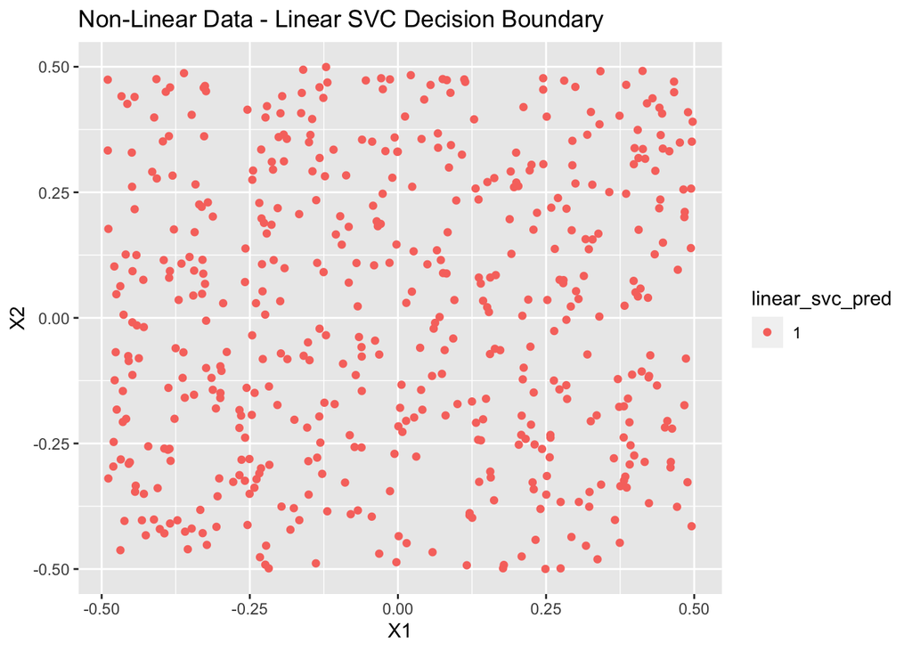

```r
linear.svc.tune <- tune(
  svm, y ~ x1 + x2, data = non.linear.data, kernel = 'linear',
  ranges = list(cost = c(0.01, 0.03, 1, 3, 10, 30, 100, 300)),
  tunecontrol = tune.control(cross = 5)
)

linear.svc.best <- linear.svc.tune$best.model
non.linear.data[['linear_svc_pred']] <- predict(
  linear.svc.best, data = non.linear.data, type = 'response'
)

non.linear.data %>% ggplot(aes(x = x1, y = x2, col = linear_svc_pred)) +
  geom_point() +
  labs(x = 'X1', y = 'X2', title = 'Non-Linear Data - Linear SVC Decision Boundary')
```

Linear SVC is practically useless. It just predicts one of the two classes.

### Part (g)

**Fit a SVM using a non-linear kernel to the data. Obtain a class prediction for each training observation. Plot the observations, colored according to the predicted class labels.**

For simplicity, I will fit a polynomial kernel SVC, cross-validated to find the optimal degree.

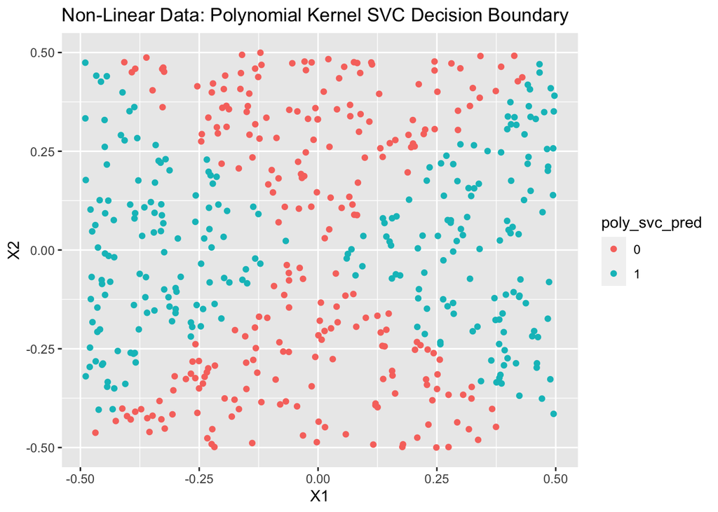

```r
poly.svc.tune <- tune(
  svm,
  y ~ x1 + x2,
  data = non.linear.data, kernel = 'polynomial',
  ranges = list(
    cost = c(0.01, 0.03, 1, 3, 10, 100),
    degree = c(1, 2, 3, 4)
  ),
  tunecontrol = tune.control(cross = 5)
)

poly.svc.best <- poly.svc.tune$best.model

non.linear.data[['poly_svc_pred']] <- predict(
  poly.svc.best, newdata = non.linear.data, type = 'response'
)

non.linear.data %>% ggplot(aes(x = x1, y = x2, col = poly_svc_pred)) +
  geom_point() +
  labs(x = 'X1', y = 'X2',
       title = 'Non-Linear Data: Polynomial Kernel SVC Decision Boundary')
```

### Part (i)

**Comment on your results.**

```r
non.linear.data %>%
  dplyr::summarize(
    err_rate_log_reg = mean(y != log_reg_pred),
    err_rate_log_reg_poly = mean(y != log_reg_poly_pred),
    err_rate_lin_svc = mean(y != linear_svc_pred),
    err_rate_poly_svc = mean(y != poly_svc_pred)
  )
```

```
##   err_rate_log_reg err_rate_log_reg_poly err_rate_lin_svc err_rate_poly_svc
## 1            0.478                     0            0.484             0.016
```

## Exercise 06 - Barely Separable Data

**At the end of Section 9.6.1, it is claimed that in the case of data that is just barely linearly separable, a support vector classifier with a small value of `cost` that misclassifies a couple of training observations may perform better on test data than ne with a high value of `cost` that does not misclassify any training observations. You will now investigate this claim.**

### Part (a)

**Generate a two-class data with $p = 2$ in such a way that the classes are just barely linearly separable.**

For simplicity, I will use code that is very similar to the ones provided in the examples.

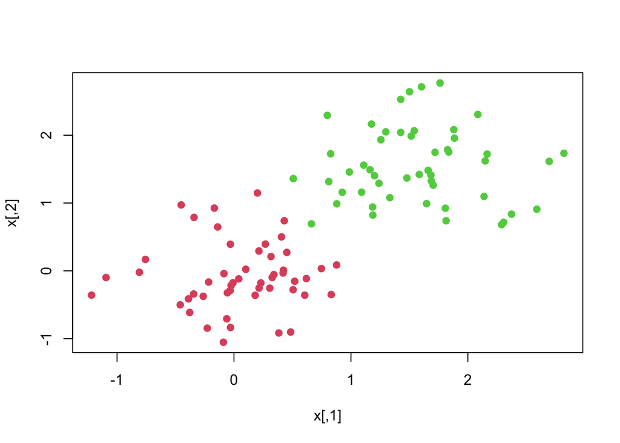

```r
set.seed(1)
x <- matrix(rnorm(100 * 2, sd = 0.55), ncol = 2)    # 20 observations, 2 predictors
y <- c(rep(-1, 50), rep(1, 50))         # Half belong to each class
x[y == 1, ] <- x[y == 1, ] + 1.0        # We offset each predictor for a class by 1
x[y == 1, ] <- x[y == 1, ] + 0.5
plot(x, col = (y + 5) / 2, pch = 19)
```

```r
svc.data <- data.frame(x = x, y = factor(y))
train.idx <- sample(1:100, 100 * 0.8)
test.idx <- (-train.idx)
```

### Part (b)

**Compute the cross-validation error rates for support vector classifiers with a range of `cost` values. How many training errors are misclassified for each value of `cost` considered, and how does this relate to the cross-validation errors obtained?**

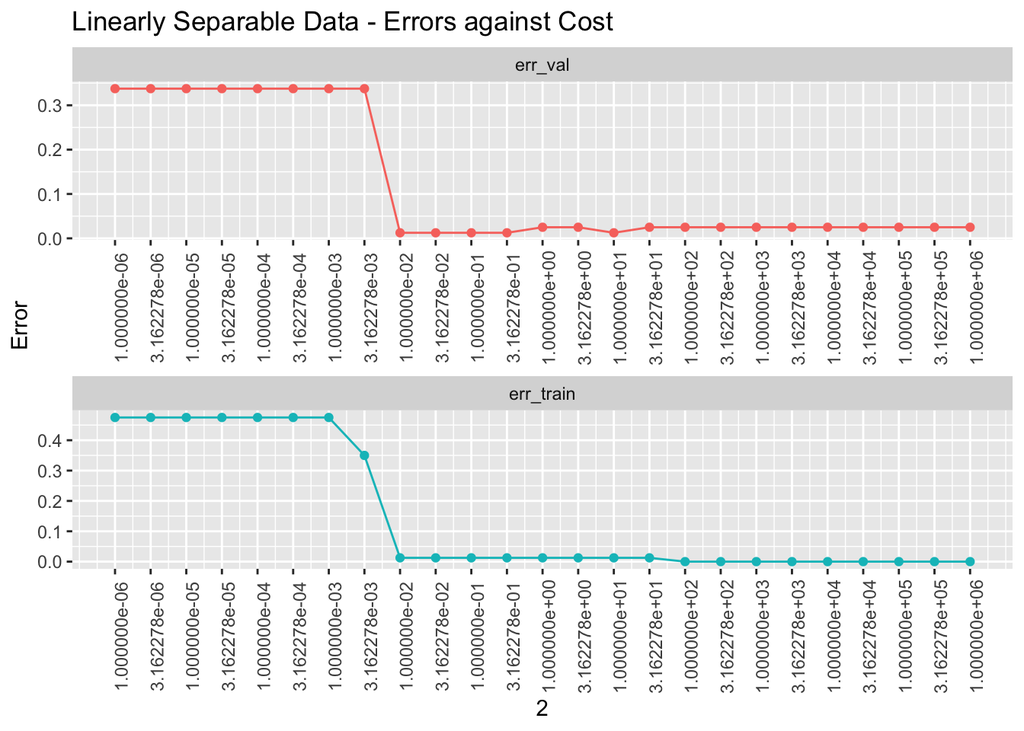

```r
set.seed(1)

# This object stores the cross-validation results
linear.svc.tune <- tune(
  svm, y ~ ., data = svc.data[train.idx, ], kernel = 'linear',
  ranges = list(cost = 10^seq(-6, 6, 0.5)),
  tunecontrol = tune.control(cross = 5)
)
linear.svc.val.results <- linear.svc.tune$performances

# This object stores the training results
linear.svc.train.results <- list()
for (i in 10^seq(-6, 6, 0.5)) {
  my.svm <- svm(y ~ ., data = svc.data[train.idx, ], kernel = 'linear', cost = i)
  train.pred <- predict(my.svm, newdata = svc.data[train.idx, ], type = 'response')
  linear.svc.train.results[[as.character(i)]] <- mean(train.pred != svc.data[train.idx, ]$y)
}

linear.svc.train.results.df <- data.frame(cost = as.numeric(names(linear.svc.train.results)),
                                          error = unlist(unname(linear.svc.train.results)))

err.df.final <- data.frame(
  cost = linear.svc.val.results$cost,
  err_val = linear.svc.val.results$error,
  err_train = linear.svc.train.results.df$error
)

err.df.final %>% data.table::melt(id.vars = 'cost') %>%
  ggplot(aes(x = cost, y = value, color = variable, group = variable)) +
  geom_point() +
  geom_line() +
  facet_wrap(variable ~., scales = 'free', nrow = 2) +
  scale_x_continuous(trans = 'log10', breaks = 10^seq(-6, 6, 0.5), 2) +
  labs(x = 'Cost', y = 'Error', title = 'Linearly Separable Data - Errors against Cost') +
  theme(axis.text.x = element_text(angle = 90), legend.position = 'none')
```

There are 100 observations. For all `cost` values above 0.01, we observe practically 0 misclassified data points. This trend is also consistent in the validation data.

Training set indicates optimal cost is 100, whereas validation suggests optimal cost is 10 or 0.01.

This means for the training data, error is minimised when there is a very high cost associated with a margin violation, so there will be very few margin violations resulting in a very narrow margin.

The validation set suggests that it might be better to use a soft margin classifier which allows for some margin violations and doesn’t incur as severe a penalty for them, in the interest of mitigating overfitting.

### Part (c)

**Generate an appropriate test data set, and compare the test errors corresponding to each of the values of `cost` considered. Which value of `cost` leads to the fewest errors, and how does this compare to the values of `cost` that yield the fewest training errors and the fewest cross-validation errors?**

```r
# Train two SVCs - one with cost 0.01 and another with cost 100
svc.fit.cost_0_01 <- svm(y ~ .,
                         data = svc.data[train.idx, ], kernel = 'linear', cost = 0.01)
svc.fit.cost_100 <- svm(y ~ .,
                        data = svc.data[train.idx, ], kernel = 'linear', cost = 100)

# Make predictions and store in a dataframe
my.test.data <- data.frame(
  x1 = svc.data[test.idx, ]$x.1, x2 = svc.data[test.idx, ]$x.2, y = svc.data[test.idx, ]$y,
  pred_svc_cost_0_01 = predict(svc.fit.cost_0_01, newdata = svc.data[test.idx, ], type = 'response'),
  pred_svc_cost_100 = predict(svc.fit.cost_100, newdata = svc.data[test.idx, ], type = 'response')
)

# Get percentage of training errors for each prediction
my.test.data %>%
  dplyr::summarize(
    count = dplyr::n(),
    err_rate_cost_0_01 = mean(pred_svc_cost_0_01 != y),
    err_rate_cost_100 = mean(pred_svc_cost_100 != y),
    identical_pred = mean(pred_svc_cost_0_01 == pred_svc_cost_100)
  )
```

```
##   count err_rate_cost_0_01 err_rate_cost_100 identical_pred
## 1    20                  0                 0              1
```

### Part (d)

**Discuss your results.** Results are counterintuitive. I expected the error rate to be much higher for a cost of 100 compared to a cost of 0.01. But it seems like on this specific test set, the two variants of the SVC lead to identical predictions, and practically no errors.

Validation set and training set errors also tell a similar story: that a higher cost and a lower cost don’t necessarily lead to worse predictions. Might be a consequence of the small training and test set size.

## Exercise 07 - Support Vector Approaches for `Auto`

**In this problem, you will use support vector approaches in order to predict whether a given car gets high or low gas mileage based on the `Auto` data set.**

### Part (a)

**Create a binary variable that takes on a 1 for cars with gas mileage above the median and a 0 for cars with gas mileage below the median.**

```r
# Creating the new binary target and removing `mpg` from the list of predictors
# otherwise information leak

my.auto <- Auto %>%
  dplyr::mutate(high_mileage = factor(mpg > median(mpg))) %>%
  dplyr::select(-mpg)
```

### Part (b)

**Fit a support vector classifier to the data with various values of `cost`, in order to predict whether a car gets high or low gas mileage. Report the cross-validation errors associated with different values of the parameter. Comment on your results. Note that you’ll need to fit the classifier without the gas mileage variable to produce sensible results.**

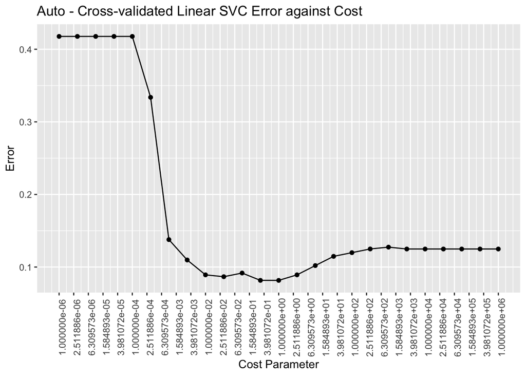

```r
auto.svc.tune <- tune(svm, high_mileage ~ ., data = my.auto, kernel = 'linear',
                      ranges = list(cost = 10^seq(-6, 6, 0.5)),
                      tunecontrol = tune.control(cross = 5))

auto.svc.tune.search <- auto.svc.tune$performances
auto.svc.tune.search %>%
  ggplot(aes(x = cost, y = error)) +
  geom_point() +
  geom_line() +
  scale_x_continuous(trans = 'log10', breaks = 10^seq(-6, 6, 0.4)) +
  labs(x = 'Cost Parameter', y = 'Error', title = 'Auto - Cross-validated Linear SVC Error against Cost') +
  theme(axis.text.x = element_text(angle = 90))
```

```r
message("Best performance with a linear SVC")
```

```
## Best performance with a linear SVC
```

```r
auto.svc.tune$best.model
```

```
##
## Call:
## best.tune(method = svm, train.x = high_mileage ~ ., data = my.auto,
##     ranges = list(cost = 10^seq(-6, 6, 0.5)), tunecontrol = tune.control(cross = 5),
##     kernel = "linear")
##
##
## Parameters:
##    SVM-Type:  C-classification
##  SVM-Kernel:  linear
##        cost:  1
##
## Number of Support Vectors:  118
```

```r
auto.svc.tune$best.performance
```

```
## [1] 0.08162934
```

### Part (c)

**Now repeat (b), this time using SVMs with radial and polynomial basis kernels, with different values of `gamma` and `degree` and `cost`. Comment on your results.**

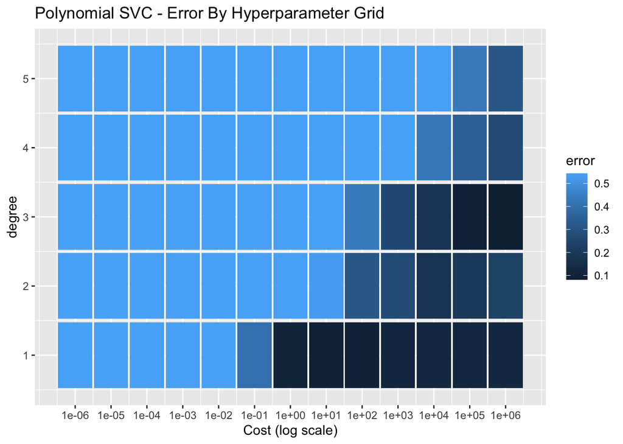

```r
auto.svm.poly.tune <- tune(
  svm, high_mileage ~ ., data = my.auto, kernel = 'polynomial',
  ranges = list(cost = 10^seq(-6, 6, 1), degree = c(1, 2, 3, 4, 5)),
  tunecontrol = tune.control(cross = 5)
)

auto.svm.radial.tune <- tune(
  svm, high_mileage ~ ., data = my.auto, kernel = 'radial',
  ranges = list(cost = 10^seq(-6, 6, 1), gamma = c(1, 2, 3, 4, 5)),
  tunecontrol = tune.control(cross = 5)
)

# Make a 2D density plot showing how cross-validated error varies with each param
auto.svm.poly.tune$performances %>%
  ggplot(aes(x = cost, y = degree, fill = error )) +
  scale_x_continuous(trans = 'log10', breaks = 10^seq(-6, 6, 1)) +
  geom_tile(aes(width = 0.95, height = 0.95)) +
  labs(title = 'Polynomial SVC - Error By Hyperparameter Grid',
                     x = 'Cost (log scale)')
```

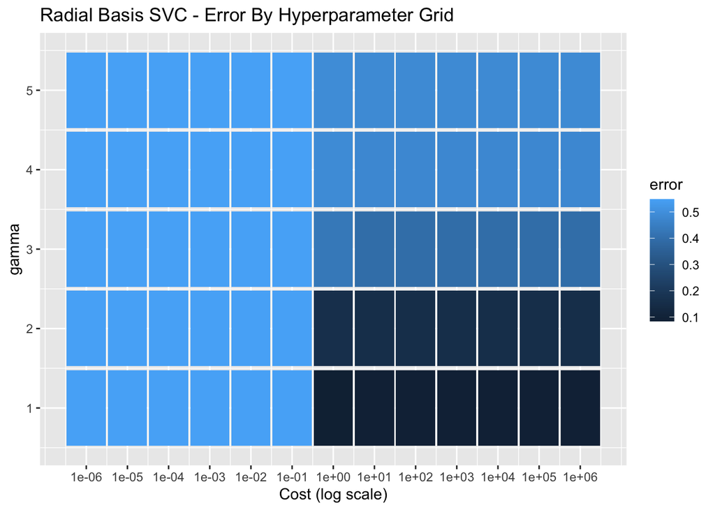

```r
# Make a similar density plot for the radial basis grid search
auto.svm.radial.tune$performances %>%
  ggplot(aes(x = cost, y = gamma, fill = error )) +
  scale_x_continuous(trans = 'log10', breaks = 10^seq(-6, 6, 1)) +
  geom_tile(aes(width = 0.95, height = 0.95)) +
  labs(title = 'Radial Basis SVC - Error By Hyperparameter Grid',
                     x = 'Cost (log scale)')
```

```r
# Outputting best parameters for each model
message("Best parameters for the polynomial SVM")
```

```
## Best parameters for the polynomial SVM
```

```r
auto.svm.poly.tune$best.model
```

```
##
## Call:
## best.tune(method = svm, train.x = high_mileage ~ ., data = my.auto,
##     ranges = list(cost = 10^seq(-6, 6, 1), degree = c(1, 2, 3, 4,
##         5)), tunecontrol = tune.control(cross = 5), kernel = "polynomial")
##
##
## Parameters:
##    SVM-Type:  C-classification
##  SVM-Kernel:  polynomial
##        cost:  1e+06
##      degree:  3
##      coef.0:  0
##
## Number of Support Vectors:  124
```

```r
auto.svm.poly.tune$best.performance
```

```
## [1] 0.08169426
```

```r
message("--------------------------------------")
message("Best parameters for the radial SVM")
```

```
## Best parameters for the radial SVM
```

```r
auto.svm.radial.tune$best.model
```

```
##
## Call:
## best.tune(method = svm, train.x = high_mileage ~ ., data = my.auto,
##     ranges = list(cost = 10^seq(-6, 6, 1), gamma = c(1, 2, 3, 4,
##         5)), tunecontrol = tune.control(cross = 5), kernel = "radial")
##
##
## Parameters:
##    SVM-Type:  C-classification
##  SVM-Kernel:  radial
##        cost:  1
##
## Number of Support Vectors:  376
```

```r
auto.svm.radial.tune$best.performance
```

```
## [1] 0.08406362
```

### Part (d)

**Make some plots to back up your assertions.** See above

## Exercise 08 - Support Vectors with `OJ` Data Set

**This problem involves the `OJ` data set which is part of the `ISLR2` package.**

### Part (a)

**Create a training set containing a random sample of 800 observations and a test set containing a random sample of 800 observations, and a test set containing the remaining observations.**

```r
set.seed(163)
oj.train.idx <- sample(1:nrow(OJ), 800)
oj.test.idx <- (-oj.train.idx)
```

### Part (b)

**Fit a support vector classifier to the training data using `cost = 0.01` with `Purchase` as the response and the other variables as the predictors. Use the `summary` function to produce summary statistics, and describe the results obtained.**

```r
# First, fit the 'default' linear SVC to the training data
oj.svc.linear.default <- svm(Purchase ~., data = OJ[oj.train.idx, ],
                             kernel = 'linear', cost = 0.01)

# Check summary
summary(oj.svc.linear.default)
```

```
##
## Call:
## svm(formula = Purchase ~ ., data = OJ[oj.train.idx, ], kernel = "linear",
##     cost = 0.01)
##
##
## Parameters:
##    SVM-Type:  C-classification
##  SVM-Kernel:  linear
##        cost:  0.01
##
## Number of Support Vectors:  427
##
##  ( 214 213 )
##
##
## Number of Classes:  2
##
## Levels:
##  CH MM
```

A low cost leads to ~427 support vectors in a data set of 800 training examples. The vectors are more or less equally distributed between the two classes. We expect a lot of margin violations with such a low cost, and generally a very large margin as well.

### Part (c)

**What are the training and test error rates?**

```r
oj.svc.linear.default.pred.train <- predict(
  oj.svc.linear.default, newdata = OJ[oj.train.idx, ]
)

oj.svc.linear.default.pred.test <- predict(
  oj.svc.linear.default, newdata = OJ[oj.test.idx, ]
)

oj.svc.linear.train.err <- mean(oj.svc.linear.default.pred.train != OJ[oj.train.idx,]$Purchase)
oj.svc.linear.test.err <- mean(oj.svc.linear.default.pred.test != OJ[oj.test.idx,]$Purchase)

message(paste0("The train error rate is : ", round(oj.svc.linear.train.err, 2)))
```

```
## The train error rate is : 0.16
```

```r
message(paste0("The test error rate is : ", round(oj.svc.linear.test.err, 2)))
```

```
## The test error rate is : 0.17
```

### Part (d)

**Use the `tune` function to select an optimal `cost`. Consider values n the range 0.01 to 10.**

```r
oj.svc.linear.tune <- tune(svm, Purchase ~., data = OJ[train.idx, ], kernel = 'linear',
                           ranges = list(cost = seq(0.01, 10, 0.05)))
oj.svc.linear.tune$best.model
```

```
##
## Call:
## best.tune(method = svm, train.x = Purchase ~ ., data = OJ[train.idx,
##     ], ranges = list(cost = seq(0.01, 10, 0.05)), kernel = "linear")
##
##
## Parameters:
##    SVM-Type:  C-classification
##  SVM-Kernel:  linear
##        cost:  0.01
##
## Number of Support Vectors:  29
```

### Part (e)

**Compute the training and test error rates using this new value for `cost`.**

```r
oj.svc.linear.best.pred.train <- predict(oj.svc.linear.tune$best.model, OJ[train.idx, ])
oj.svc.linear.best.pred.test <- predict(oj.svc.linear.tune$best.model, OJ[test.idx, ])

oj.svc.linear.best.train.err <- mean(oj.svc.linear.best.pred.train != OJ[train.idx, ]$Purchase)
oj.svc.linear.best.train.err <- mean(oj.svc.linear.best.pred.test != OJ[test.idx, ]$Purchase)

message(paste0("The train error rate is : ", round(oj.svc.linear.best.train.err, 2)))
```

[output not shown]

```r
message(paste0("The test error rate is : ", round(oj.svc.linear.best.train.err, 2)))
```

```
## The test error rate is : 0.41
```

### Part (e)

**Repeat parts (b) through (e) using a support vector machine with a radial kernel. Use the default value of `gamma`.**

```r
set.seed(163)
oj.svm.radial.basic <- svm(Purchase ~., data = OJ[train.idx, ], kernel = 'radial')
summary(oj.svm.radial.basic)
```

```
##
## Call:
## svm(formula = Purchase ~ ., data = OJ[train.idx, ], kernel = "radial")
##
##
## Parameters:
##    SVM-Type:  C-classification
##  SVM-Kernel:  radial
##        cost:  1
##
## Number of Support Vectors:  43
##
##  ( 11 32 )
##
##
## Number of Classes:  2
##
## Levels:
##  CH MM
```

```r
message(
  "Training Error for Base Radial SVM is: ",
  round(mean(OJ[oj.train.idx, ]$Purchase != predict(oj.svm.radial.basic, OJ[oj.train.idx, ])),2)
)
```

```
## Training Error for Base Radial SVM is: 0.39
```

```r
message(
  "Test Error for Base Radial SVM is: ",
  round(mean(OJ[oj.test.idx, ]$Purchase != predict(oj.svm.radial.basic, OJ[oj.test.idx, ])), 2)
)
```

```
## Test Error for Base Radial SVM is: 0.38
```

```r
# Tune the SVM
oj.svm.radial.tune <- tune(svm, Purchase ~ ., data = OJ[oj.train.idx, ], kernel = 'radial',
                    ranges = list(cost = seq(0.01, 10, 0.05)))
oj.svm.radial.tune$best.parameters
```

```
##    cost
## 28 1.36
```

```r
oj.svm.radial.best <- oj.svm.radial.tune$best.model
message("Best cross-validated performance for radial SVM: ", oj.svm.radial.tune$best.performance)
```

```
## Best cross-validated performance for radial SVM: 0.155
```

```r
message(
  "Training Error for Tuned Radial SVM is: ",
  round(mean(OJ[oj.train.idx, ]$Purchase != predict(oj.svm.radial.best, OJ[oj.train.idx, ])),2)
)
```

```
## Training Error for Tuned Radial SVM is: 0.14
```

```r
message(
  "Test Error for Tuned Radial SVM is: ",
  round(mean(OJ[oj.test.idx, ]$Purchase != predict(oj.svm.radial.best, OJ[oj.test.idx, ])), 2)
)
```

```
## Test Error for Tuned Radial SVM is: 0.21
```

### Part (f)

**Repeat parts (b) through (e) using a support vector machine with a polynomial kernel. Set `degree = 2`.**

```r
set.seed(163)
oj.svm.poly.basic <- svm(Purchase ~., data = OJ[train.idx, ], kernel = 'polynomial',
                         degree = 2)
summary(oj.svm.poly.basic)
```

```
##
## Call:
## svm(formula = Purchase ~ ., data = OJ[train.idx, ], kernel = "polynomial",
##     degree = 2)
##
##
## Parameters:
##    SVM-Type:  C-classification
##  SVM-Kernel:  polynomial
##        cost:  1
##      degree:  2
##      coef.0:  0
##
## Number of Support Vectors:  32
##
##  ( 11 21 )
##
##
## Number of Classes:  2
##
## Levels:
##  CH MM
```

```r
message(
  "Training Error for Base Poly SVM is: ",
  round(mean(OJ[oj.train.idx, ]$Purchase != predict(oj.svm.poly.basic, OJ[oj.train.idx, ])),2)
)
```

```
## Training Error for Base Poly SVM is: 0.33
```

```r
message(
  "Test Error for Base Poly SVM is: ",
  round(mean(OJ[oj.test.idx, ]$Purchase != predict(oj.svm.poly.basic, OJ[oj.test.idx, ])), 2)
)
```

```
## Test Error for Base Poly SVM is: 0.36
```

```r
# Tune the SVM
oj.svm.poly.tune <- tune(svm, Purchase ~ ., data = OJ[oj.train.idx, ], kernel = 'polynomial',
                         degree = 2, ranges = list(cost = seq(0.01, 10, 0.05)))
oj.svm.poly.tune$best.parameters
```

```
##     cost
## 185 9.21
```

```r
oj.svm.poly.best <- oj.svm.poly.tune$best.model
message("Best cross-validated performance for poly SVM: ", oj.svm.poly.tune$best.performance)
```

```
## Best cross-validated performance for poly SVM: 0.16125
```

```r
message(
  "Training Error for Tuned Poly SVM is: ",
  round(mean(OJ[oj.train.idx, ]$Purchase != predict(oj.svm.poly.best, OJ[oj.train.idx, ])),2)
)
```

```
## Training Error for Tuned Poly SVM is: 0.14
```

```r
message(
  "Test Error for Tuned Poly SVM is: ",
  round(mean(OJ[oj.test.idx, ]$Purchase != predict(oj.svm.poly.best, OJ[oj.test.idx, ])), 2)
)
```

```
## Test Error for Tuned Poly SVM is: 0.21
```